# Willamette Falls Fish Passage

Kristin Gill, Julianna Renzi, AJ Zekanoski

2/09/2021

```r
# reading in the data
fish_passage <- read_csv(here("data", "willamette_fish_passage.csv")) %>%
  clean_names() %>%
  pivot_longer(cols = 3:15, names_to = "species", values_to = "counts")  %>%
  mutate(date_new = mdy(date)) %>%
  filter(species %in% c("coho", "jack_coho", "steelhead")) %>%
  as_tsibble(key = species,
             index = date_new)
```

# Overview

This dataset shows the number of fishes that have passed through the Willamette Falls Fish Ladder on the Willamette River in Oregon. Counts are taken from video recordings of the ladder every day, 24 hours/day, with only short breaks in data collection in 2005, 2008, and 2010 (11/29/2005-12/1/2005, 12/6/2005-12/8/2005, 12/13/2005-12/14/2005, 8/26/2008-9/21/2008, 8/23/2010-8/27/2010). In this report we examine patterns of Coho, Jack Coho, and Steelhead abundance through time at the Willamette Fish Ladder.

We first examine the full time series (first tab) to look for general trends in the data, then we divided the data up by year to see how fish abundance varies seasonally and by year (second tab), and finally we look at annual counts by species (third tab) to see how abundances are changing through time.

**Data source:**

Columbia Basin Research. DART Adult Passage Daily Counts For All Species for WFF-Willamette Falls. Dates: 2001-01-01 to 2010-12-31. Accessed: 2021-01-29. School of Aquatic & Fishery Sciences, University of Washington. URL: http://www.cbr.washington.edu/dart/query/adult_graph_text

# Data Visualizations

## Time Series

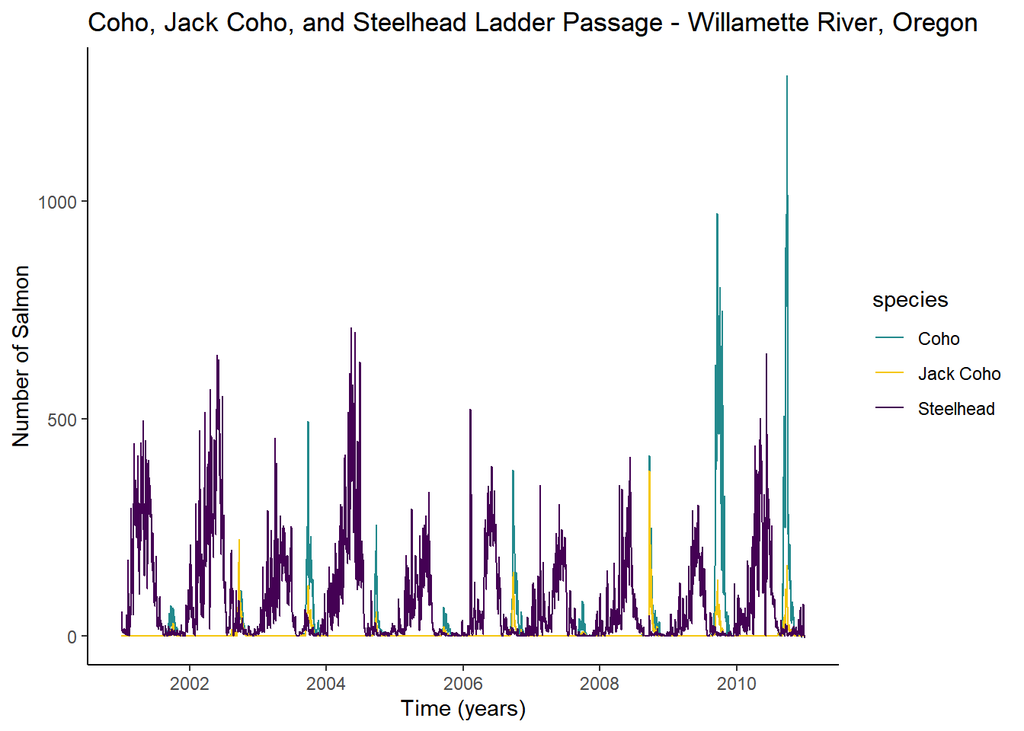

**Figure 1:** Coho, Jack Coho, and Steelhead passage through the Willamette Falls fish ladder on the Willamette River, Oregon, starting in 2001 and through 2010. Coho is indicated in green, Jack Coho is indicated in yellow, and Steelhead is indicated in purple. Data from: Colombia Basin Research. School of Aquatic & Fishery Science, University of Washington. Date accessed: 2021-01-29. http://www.cbr.washington.edu/dart/query/adult_graph_text

```r
tab_1 <- fish_passage %>%
  select(species, date_new, counts) %>%
  mutate_if(is.numeric, ~replace(., is.na(.), 0)) %>%
  mutate(year = year(date_new)) %>%
  mutate(species = case_when(
    species == "coho" ~ "Coho",
    species == "jack_coho" ~ "Jack Coho",
    species == "steelhead" ~ "Steelhead"
  ))

ggplot(data = tab_1, aes(x = date_new,
                         y = counts)) +
  geom_line(aes(color = species)) +
  #facet_wrap(~species, scales = "free_y") +
  labs(x = "Time (years)",
       y = "Number of Salmon",
       title = "Coho, Jack Coho, and Steelhead Ladder Passage - Willamette River, Oregon") +
  theme_classic() +
  scale_color_manual(values = c("#238A8DFF", "95D8F0FF", "#440154FF"))
```

- Fish passage tends to be higher for Steelhead and Coho.
- Fish passage varies seasonally for each species. Steelhead tend to pass through earlier in the year than Coho and Steelhead.
- Coho passage shows a marked increase in 2009 and 2010.

## Season Plots

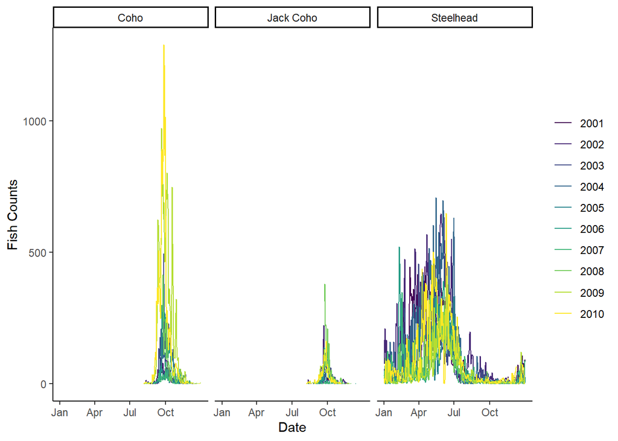

**Figure 2:** Coho, Jack Coho, and Steelhead abundance through time on the Willamette River, Oregon, for 2001-2010. Each line represents a different year. Data from: Colombia Basin Research. School of Aquatic & Fishery Science, University of Washington. Date accessed: 2021-01-29. http://www.cbr.washington.edu/dart/query/adult_graph_text

```r
# create seasonplots for each species
fish_passage %>%
  mutate(species = case_when(
    species == "coho" ~ "Coho",
    species == "jack_coho" ~ "Jack Coho",
    species == "steelhead" ~ "Steelhead"
  )) %>%
  gg_season(y = counts,
            pal = scales::viridis_pal()(9)) +
  facet_wrap("species") +
  ylab("Fish Counts") +
  xlab("Date") +
  theme_classic()
```

- Coho and Jack Coho abundances peak around October with sightings dropping off within a few months away from October in either direction. In contrast, Steelheads were counted throughout the year and their abundance peaks in the spring/summer, rather than during the fall.
- Jack Coho appear to be the least abundant of the three fishes, Coho have the largest abundance peak, and Steelheads appear to have the largest total abundance as well as the most consistent presence throughout the year.
- Coho and Jack Coho abundances appear to be increasing in time (highest peaks are later years), whereas Steelhead abundances may be decreasing (top peaks are earlier years).

## Summary Statistics and Analysis

```r
tab_3 <- read_csv(here("data", "willamette_fish_passage.csv")) %>%
  clean_names() %>%
  pivot_longer(cols = 3:15, names_to = "species", values_to = "counts")  %>%
  mutate(date_new = mdy(date)) %>%
  filter(species %in% c("coho", "jack_coho", "steelhead")) %>%
  select(species, date_new, counts) %>%
  mutate_if(is.numeric, ~replace(., is.na(.), 0)) %>%
  mutate(year = year(date_new)) %>%
   mutate(species = case_when(
    species == "coho" ~ "Coho",
    species == "jack_coho" ~ "Jack Coho",
    species == "steelhead" ~ "Steelhead")) %>%
  group_by(year, species) %>%
  summarise(count = sum(counts))
```

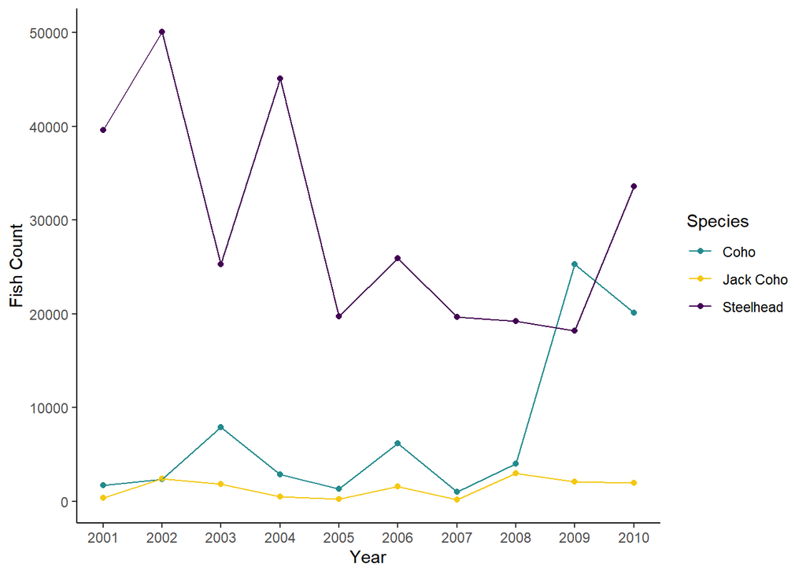

**Figure 2:** Yearly Population Abundance of Coho, Jack Coho, and Steelhead salmon recorded at the Willammette Falls fish passage. Data from: Colombia Basin Research. School of Aquatic & Fishery Science, University of Washington. Date accessed: 2021-01-29. http://www.cbr.washington.edu/dart/query/adult_graph_text

```r
ggplot(data = tab_3,
       aes(x = year, y = count, color = species)) +
  geom_point() +
  geom_line() +
  labs(x = "Year", y = "Fish Count", color = "Species") +
  scale_x_continuous(breaks=seq(2001,2010,1)) +
  theme_classic() +
  scale_color_manual(values = c("#238A8DFF", "95D8F0FF", "#440154FF"))
```